# tidyr

Haley Jeppson, Joe Papio, Sam Tyner

June 14, 2017

# The `tidyr` package

# What is tidy data?

> Happy families are all alike; every unhappy family is unhappy in its own way.  
> Leo Tolstoy
- Resource: follow along tidyr vignette
- available as `vignette("tidy-data", package="tidyr")`
- vignette is version of the [tidy data paper](https://www.jstatsoft.org/article/view/v059i10) with updated code

# Outline

- Different sources of messiness
- Key-Value pairs
- `tidyr`: `spread` and `gather`, `separate`

# Data is usually in a spreadsheet format, but…

there’s different ways of encoding the same information:

Option #1

```
##           name treatmenta treatmentb
## 1   John Smith         NA         18
## 2     Jane Doe          4          1
## 3 Mary Johnson          6          7
```

Option #2

```
##   treatment John.Smith Jane.Doe Mary.Johnson
## 1         a         NA        4            6
## 2         b         18        1            7
```

Neither #1 nor #2 are “clean” versions of the data: observed information is part of the data structure; some implicit information is assumed

# Sources of Messiness

1. Column headers are values, not variable names.  
   e.g. *treatmenta, treatmentb*
2. Multiple variables are stored in one column.  
   e.g. *Fall 2015, Spring 2016* or *“1301 8th St SE, Orange City, Iowa 51041 (42.99755, -96.04149)”, “2102 Durant, Harlan, Iowa 51537 (41.65672, -95.33780)”*
3. Multiple observational units are stored in the same table.
4. A single observational unit is stored in multiple tables.

# Tidy data

1. Each variable forms one column.
2. Each observation forms one row.
3. Each type of observational unit forms a table.

# Clean version of the example

```
##   treatment      patient score
## 1         a   John Smith    NA
## 2         b   John Smith    18
## 3         a     Jane Doe     4
## 4         b     Jane Doe     1
## 5         a Mary Johnson     6
## 6         b Mary Johnson     7
```

- `treatment` and `patient` uniquely describe a single row in the dataset.
- `treatment` and `patient` are **key variables**,
- `score` is a **measurement variable**
- this makes `treatment-patient` and `score` a **key-value pair**

# Key-value pairs (KVP)

**Key-Value pairs** (KVP) - also *attribute-value*, *field-value*, *name-value*: abstract data representation that allows a lot of flexibility

One way of telling whether a data set is tidy is to check that all keys for a value are aligned in one row:

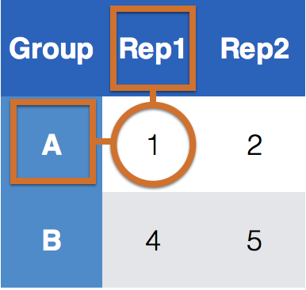

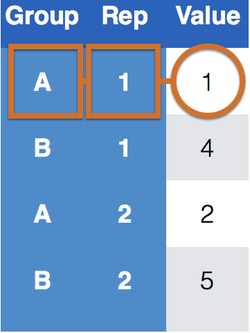

Untidy data

Tidy data

# Tidying data - Plan of attack

Very few functions are needed for tidying data:

- Messy (1): `tidyr` functions `gather` and `spread`.  
  `gather (data, key, value, ...)`: take multiple columns and collapse into key-value pairs  
  `spread (data, key, value, fill = NA)`: spread a key-value pair across multiple columns.
- Messy (2): `tidyr` function `separate (data, col, into, sep = "[^[:alnum:]]+")`: separate one column into multiple columns
- Messy (3): `dplyr` - some combination of the functions discussed previously
- Messy (4): `dplyr` functionality `join` (and friends) to combine multiple data sets

# Gather

```r
ffm <- french_fries %>% gather(key = scale, value = score, 5:9)
ffm
```

```
##      time treatment subject rep   scale score
## 1       1         1       3   1  potato   2.9
## 2       1         1       3   2  potato  14.0
## 3       1         1      10   1  potato  11.0
## 4       1         1      10   2  potato   9.9
## 5       1         1      15   1  potato   1.2
## 6       1         1      15   2  potato   8.8
## 7       1         1      16   1  potato   9.0
## 8       1         1      16   2  potato   8.2
## 9       1         1      19   1  potato   7.0
## 10      1         1      19   2  potato  13.0
## 11      1         1      31   1  potato  12.2
## 12      1         1      31   2  potato  12.8
## 13      1         1      51   1  potato   8.6
## 14      1         1      51   2  potato  10.2
```

[output cut: 3466 more lines]

# Spread

```r
ffm %>% spread(key = rep, value = score)
```

```
##      time treatment subject   scale    1    2
## 1       1         1       3 buttery  0.0  0.0
## 2       1         1       3  grassy  0.0  0.0
## 3       1         1       3  painty  5.5  0.0
## 4       1         1       3  potato  2.9 14.0
## 5       1         1       3  rancid  0.0  1.1
## 6       1         1      10 buttery  6.4  5.9
## 7       1         1      10  grassy  0.0  2.9
## 8       1         1      10  painty  0.0  0.0
## 9       1         1      10  potato 11.0  9.9
## 10      1         1      10  rancid  0.0  2.2
## 11      1         1      15 buttery  0.1  3.0
## 12      1         1      15  grassy  0.0  3.6
## 13      1         1      15  painty  5.1  2.3
## 14      1         1      15  potato  1.2  8.8
```

[output cut: 1726 more lines]

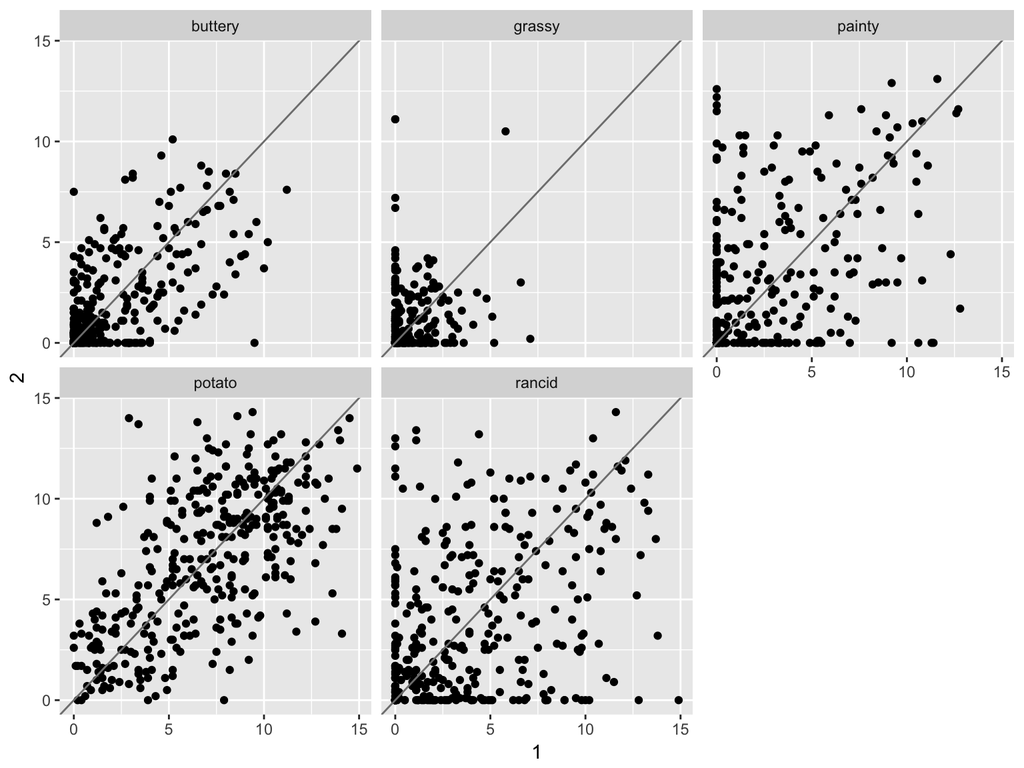

```r
ffm %>% spread(key = rep, value = score) %>%
  ggplot(aes(x = `1`, y = `2`)) + geom_point() +
  facet_wrap(~scale) + geom_abline(colour = "grey50")
```

# separate

```r
df <- data.frame(x = c(NA, "a.b", "a.d", "b.c"))
df %>% separate(x, into = c("A", "B"))
```

```
##      A    B
## 1 <NA> <NA>
## 2    a    b
## 3    a    d
## 4    b    c
```

# Your Turn (5 min)

The Iowa Data Portal is a wealth of information on and about the State of Iowa.

The website [Campaign Expenditures](https://data.iowa.gov/Government/Campaign-Expenditures/3adi-mht4/data) provides data on campaign expenditures. The code below reads the data into an R session.

```
url <- "https://data.iowa.gov/api/views/3adi-mht4/rows.csv"
campaign <- readr::read_csv(url)
```

Assess the ‘messiness’ of the data. List issues that prevent us from working with the data directly. Which of these issues are of type (1) or (2) of messiness?

# Problems with the data

- `Date` is text, in the format of Month/Day/Year (Messy 2)
- city coordinates are a combination of City name, state, zip code and geographic latitude and longitude. (Messy 2)
- expenditure amount is a textual expression, not a number (Messy different)

no Messy 1? - problems of type Messy 1 are typically hard to detect and often up to interpretation/dependent on the analysis to be done.

# Your Turn (10 min)

- Check the help for the function `parse_number` in the `readr` package and use it on the campaign expenditure data.
- Use `separate` to split the date variable into year, month and day.
- Use `separate` again to extract geographic latitude and longitude (Hint - you might need several steps of `separate`)
- Using `dplyr` functionality answer the following questions:
1. What is the total amount of campaign expenditure?
2. What is the single largest cost in the campaign expenditures?
3. What time frame does the campaign expenditure cover?
4. Plot geographic longitude and latitude. Do campaign expenditures stay in the State of IA? Investigate oddities.

# Another Your-Turn (10 mins)

During the 1870 census data on people’s occupation was collected. The data occupation-1870 contains state-level aggregates of occupation by gender.

- Use `tidyr` to get the data into a long format.
- Separate the `occupation.gender` type variable into two variables.
- Spread the data such that you can draw scatterplots of values for men against women facetted by occupation.

# Your Turn - Sample Solution

```r
occupation <- read.csv("../data/occupation-1870.csv")

# combine all of the variables (except for State)
# into a single variable
occupation <- occupation %>%
  gather(key="Occ.gender", value="Number", 2:11)
occupation
```

```
##                Area.name Total.Population           Occ.gender Number
## 1                Alabama           996992     Agriculture.Male 226768
## 2      Arizona Territory             9658     Agriculture.Male   1284
## 3               Arkansas           484471     Agriculture.Male 100669
## 4             California           560247     Agriculture.Male  47580
## 5     Colorado Territory            39864     Agriculture.Male   6462
## 6            Connecticut           537454     Agriculture.Male  43523
## 7       Dakota Territory            14181     Agriculture.Male   2522
## 8               Delaware           125015     Agriculture.Male  15907
## 9   District of Columbia           131700     Agriculture.Male   1350
## 10               Florida           187748     Agriculture.Male  36944
## 11               Georgia          1184109     Agriculture.Male 262152
## 12       Idaho Territory            14999     Agriculture.Male   1462
## 13              Illinois          2539891     Agriculture.Male 375407
## 14               Indiana          1680637     Agriculture.Male 266349
```

[output cut: 456 more lines]

# Your Turn - Sample Solution (cont’d)

```r
# split Occ.gender into two variables
occupation <- occupation %>%
  separate(Occ.gender, into = c("Occupation", "Gender"))
occupation
```

```
##                Area.name Total.Population    Occupation Gender Number
## 1                Alabama           996992   Agriculture   Male 226768
## 2      Arizona Territory             9658   Agriculture   Male   1284
## 3               Arkansas           484471   Agriculture   Male 100669
## 4             California           560247   Agriculture   Male  47580
## 5     Colorado Territory            39864   Agriculture   Male   6462
## 6            Connecticut           537454   Agriculture   Male  43523
## 7       Dakota Territory            14181   Agriculture   Male   2522
## 8               Delaware           125015   Agriculture   Male  15907
## 9   District of Columbia           131700   Agriculture   Male   1350
## 10               Florida           187748   Agriculture   Male  36944
## 11               Georgia          1184109   Agriculture   Male 262152
## 12       Idaho Territory            14999   Agriculture   Male   1462
## 13              Illinois          2539891   Agriculture   Male 375407
## 14               Indiana          1680637   Agriculture   Male 266349
```

[output cut: 456 more lines]

# Your Turn - Sample Solution (cont’d)

```r
# now spread the data again
occ2 <- occupation %>% spread(Gender, Number)
occ2
```

```
##                Area.name Total.Population    Occupation Female   Male
## 1                Alabama           996992   Agriculture  64860 226768
## 2                Alabama           996992 Manufacturing   1992  15078
## 3                Alabama           996992        School  38539  38600
## 4                Alabama           996992       Service  22676  19449
## 5                Alabama           996992         Trade     90  14345
## 6      Arizona Territory             9658   Agriculture      1   1284
## 7      Arizona Territory             9658 Manufacturing    156    883
## 8      Arizona Territory             9658        School     70     79
## 9      Arizona Territory             9658       Service    136   2979
## 10     Arizona Territory             9658         Trade      3    588
## 11              Arkansas           484471   Agriculture   8641 100669
## 12              Arkansas           484471 Manufacturing    279   5992
## 13              Arkansas           484471        School  29504  33068
## 14              Arkansas           484471       Service   6859   8018
```

[output cut: 221 more lines]

# Your Turn - Sample Solution (cont’d)

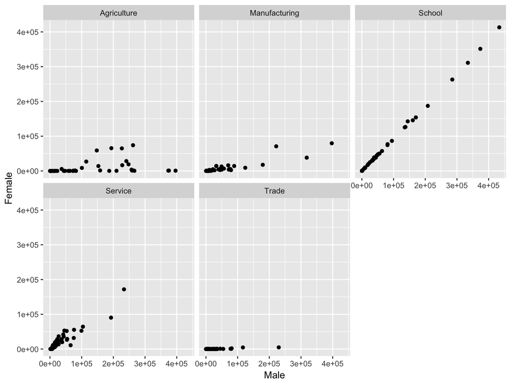

```r
occ2 %>%
  ggplot(aes(x = Male, y = Female)) + geom_point() +
  facet_wrap(~Occupation)
```